# Cartograflow

Filtering Matrix for Thematic Flow Mapping

Françoise Bahoken, Sylvain Blondeau

2020-06-03

`Cartograflow` is designed to filter origin-destination matrix for thematic flow mapping purposes using `{sf}` objects and `{Cartography}` to design the map.

## A - Description of functions

### 1. Preparing flow data sets

#### 1.1 General functions

You can use long “L” or matrix “M” [n*n] flow dataset formats.

– `flowtabmat()` is to transform “L” to “M” formats, also to build an empty square matrix from spatial codes.

– `flowcarre()` is to square a matrix.

– `flowjointure()` is to performs a spatial join between a flow dataset and a spatial features layer (as a map background) or an external matrix.

– `flowstructmat()` fixes an unpreviously codes shift in the flow dataset “M” format. If necessary this function is to be used with `flowjointure` and `flowtabmat`.

#### 1.2. Flow computing

– `flowtype()` is to compute volumn and balance flow from observed flows - respectively to compute symetric and skewmetric matrix from an asymmetric one.

#### 1.3. Flow reduction

– `flowreduct()` is to reduce the flow dataset regarding another matrix, e.g. distances travelled.

- `metric` is the metric of the distance matrix : *continuous* (e.g. for meters) or *ordinal* (e.g. for adjacency).

If the metric is continuous (e.g for filtering flows by kilometric distances travelled), use:

- `d.criteria` is for selecting *dmin* or *dmax* distance criteria for “continuous” metric ; Argument `dmin` is for keeping only flows up to a *dmin* criterion in km ; Argument `dmax` for selecting values less than a *dmax* criterion in km.
- `d` is the value of the selected *dmin* or *dmax* criteria.

Notice that these arguments can be used as a filter criterion in `flowmap()`.

### 2. Filtering flows

#### 2.1. Filtering flows from concentration analysis

**Flow concentration analysis:**

– `flowgini()` performs a Gini’s concentration analysis of the flow features, by computing *Gini coefficient* and plotting interactive *Lorenz curve*.

To be use before `flowanalysis()`

**Flow filtering according to a concentration criterion:**

– `flowanalysis()` computes filters criterions based on:

- argument *critflow* is to filter the flows according to their significativity (% of total of flow information) ;
- argument *critlink* is to filter the flows according to their density (% of total features)

These arguments can be used as filter criterion in `flowmap()`.

#### 2.2. Spatial / territorial filtering of flows

**Flow filtering based on a continuous distance criterion**

– `flowdist()` computes a *continous distance* matrix from spatial features (area or points). The result is a matrix of the distances travelled between ODs, with flows filtered or not.

**Flow filtering based on an ordinal distance / neighbourhood criterion**:

– `flowcontig()` compute an *ordinal distance* matrix from spatial features (area). The result is a matrix of adjacency or k-contiguity of the ODs.

- `background` is the areal spatial features ;
- `code` is the spatial features codes ;
- `k` is to enter the number (k:1,2,…,k) of the contiguity matrix to be constructed : if (k=1), ODs places are adjacent, then the flow have to cross only 1 boundary, else (k=k) ODs places are distant from n borders ;
- `algo` is the algorithm to use for ordinal distance calculation (also Default is “automatic” for “Dijkstra’s”) ;

Notice that the function automatically returns the maximum (k) number of the spatial layer.

### 3. Flow mapping

– `flowmap()` is to plot flows as segments or arrows, by acting on the following arguments:

- `filter` is to filter or not flow’s information or features
- `threshold` is used to set the filtering level of the flows when filter= *“True”*
- `taille` is the value of the width of the flow feature
- `a.head` is the arrow head parameter (in, out, in and out)
- `a.length` is the length of the edges of the arrow head (in inches)
- `a.angle` is the angle from the shaft of the arrow to the edge of the arrow head
- `a.col` is the arrow’s color
- `plota` is to add spatial features as map background to the flows’s plot
- `add` is to allow to overlay flow features on external spatial features background

## B- Examples of applications

Useful external packages are {dplyr} {sf} {igraph} {rlang} {cartography}.

### 1. Load datasets

**Flow dataset**

```
## 'data.frame':    121 obs. of  4 variables:
##  $ i    : chr  "T1" "T1" "T1" "T1" ...
##  $ j    : chr  "T1" "T10" "T11" "T12" ...
##  $ Fij  : num  291058 8297 3889 17064 12163 ...
##  $ count: num  351 43 13 77 52 55 134 63 53 14 ...
```

**Select variable and change matrix format**

```r
# Selecting useful variables
tabflow<-data%>%select(i,j,Fij)

# Change matrix format (if necessary)
matflow <-flowtabmat(tabflow,matlist="M")
```

```
## great:your matrix is square!
```

```r
head(matflow[1:4,1:4])
```

```
##         T1   T10   T11   T12
## T1  291058  8297  3889 17064
## T10  73743 19501 11707  4931
## T11  22408  9359 12108  6084
## T12  68625  1906  7269 46515
```

```r
#dim(matflow)

# reverse Change matrix format : from matrix to list
tabflow<-flowtabmat(tab=matflow, matlist="L")
colnames(tabflow)<-c("i","j","Fij")
head(tabflow)
```

```
##     i  j    Fij
## 1  T1 T1 291058
## 2 T10 T1  73743
## 3 T11 T1  22408
## 4 T12 T1  68625
## 5  T2 T1  47427
## 6  T3 T1  45772
```

**Geographical dataset**

```r
# Load a list of geo codes
ID_CODE<-read.csv2("./data/COD_GEO_EPT.csv",
                   header=TRUE,
                   sep=";",
                   stringsAsFactors=FALSE,
                   encoding="UTF-8",
                   dec=".",
                   check.names=FALSE)
#head(ID_CODE)

CODE<-ID_CODE%>% dplyr::select(COD_GEO_EPT)

colnames(CODE)<-c("CODGEO")
#head(CODE)
```

### 2. Flow computing

*Compute bilateral flows : volum, balance and asymetry*

```r
# Compute bilateral volum : FSij
matflow_vol<-flowtype(matflow, format="M", x="bivolum")

tabflow_vol<-flowtype(tabflow, origin ="i",destination="j",fij="Fij",format="L", x="bivolum")

# Compute bilateral balance : FSij
tabflow_net<-flowtype(tabflow, origin ="i",destination="j",fij="Fij",format="L", x="bibal")

# Compute all types of bilateral flows, in one 6 columns "L"format matrix
tabflow_all<-flowtype(tabflow, origin ="i",destination="j",fij="Fij",format="L", x="alltypes")
head(tabflow_all)
```

```
##    i   j    Fij    Fji   FSij  FBij      FAij minFij maxFij rangeFij      FDij
## 1 T1  T1 291058 291058 582116     0 0.0000000 291058 291058        0 0.0000000
## 2 T1 T10   8297  73743  82040 65446 0.7977328   8297  73743    65446 0.7977328
## 3 T1 T11   3889  22408  26297 18519 0.7042248   3889  22408    18519 0.7042248
## 4 T1 T12  17064  68625  85689 51561 0.6017225  17064  68625    51561 0.6017225
## 5 T1  T2  12163  47427  59590 35264 0.5917771  12163  47427    35264 0.5917771
## 6 T1  T3  32682  45772  78454 13090 0.1668494  32682  45772    13090 0.1668494
```

```r
# Compute flow asymetry
#tabflow_all$FAsy<-(tabflow_all$FDij / tabflow_all$FDij)*100
```

### 3. General Flow mapping

Plot all origin-destination links without any filtering criterion will reveal a graphic complexity (“spaghetti-effect”). So it is better to plot flow up to a simple global paramet (eg. mean).

**Above-average flowmap**

[figure not shown]

```r
library(sf)
data(flowdata)
map <- st_read(system.file("shape/MGP_TER.shp", package = "cartograflow"))
# Add and overlay spatial background
par(bg = "NA")

knitr::opts_chunk$set(fig.width=6, fig.height=6)
par(mar=c(0,0,1,0))
extent <- c(2800000, 1340000, 6400000, 4800000)
resolution<-150

plot(st_geometry(map), col = NA, border=NA, bg="#dfe6e1")
plot(st_geometry(map), col = "light grey", add=TRUE)

# Flow mapping above-average flows
flowmap(tab=tabflow,
        fij="Fij",
        origin.f = "i",
        destination.f = "j",
        bkg = map,
        code="EPT_NUM",
        nodes.X="X",
        nodes.Y = "Y",
        filter=TRUE,
        threshold =(mean(tabflow$Fij)),  #mean value is the level of threshold
        taille=20,
        a.head = 1,
        a.length = 0.11,
        a.angle = 30,
        a.col="#138913",
        add=TRUE)

# Map Legend
legendPropLines(pos="topleft",
                title.txt="Flows up to 13220 commuters",
                title.cex=0.8,
                cex=0.5,
                values.cex= 0.7,
                var=c(mean(tabflow$Fij),max(tabflow$Fij)),
                lwd=5,
                frame = FALSE,
                col="#138913",
                values.rnd = 0
                )

#Map cosmetic

layoutLayer(title = "Commuters up to above-average in Greater Paris",
           coltitle ="black",
           author = "Cartograflow, 2020",
           sources = "Data : INSEE, 2017 ; Basemap : APUR, RIATE, 2018.",
           scale = 2,
           tabtitle = FALSE,
           frame = TRUE,
           col = "grey"
            )

# North arrow
north("topright")
```

### 4. Concentration analysis for Flow mapping

**Main functions**

`flowgini()` and `flowanalysis()`

**Compute the concentration of flow values**

```r
tabgini<-flowgini(ODpts = tabflow,
                  origin="i",destination = "j",valflow = "Fij",
                  lorenz.plot = FALSE)
```

```
## Gini's coefficent =73.16 %
```

```r
# Interpretation ; The flows are quite concentrated on a few links, the Gini coefficent is equal to 73.16%
```

**Plot the corresponding interactive Lorenz’ curve**

```r
head(tabgini)
```

```
##      i  j    Fij link   flowcum     linkcum
## 1   T1 T1 291058    1 0.1819563 0.008264463
## 73  T1 T4  81129    1 0.2326745 0.016528926
## 2  T10 T1  73743    1 0.2787752 0.024793388
## 4  T12 T1  68625    1 0.3216765 0.033057851
## 7   T4 T1  66223    1 0.3630761 0.041322314
## 11  T8 T1  58770    1 0.3998165 0.049586777
```

```r
flowgini(ODpts = tabflow,
         origin="i",destination = "j",valflow = "Fij",
         lorenz.plot = TRUE)
```

[interactive chart not shown]

**Compute the “critflow” parameter (ex. significance)**

```r
flowanalysis(tabgini,
             critflow = 0.8,
             result = "signif")
```

```
## [1] "threshold =  13442  ---  flows =  80 % ---  links =  23.14 %"
```

```r
# Interpretation : Flow values up to 13442 are the 80% largest one corresponding to 23,14 % of the total links' features.
```

**Flowmap filtered according to flows values significance**

Using the `flowanalysis()` *“critflow”* value to select flows.

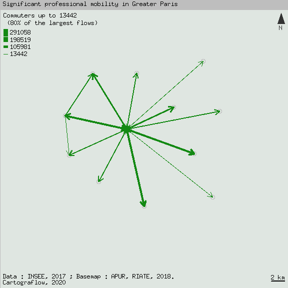

```r
# Graphic parameters
knitr::opts_chunk$set(fig.width=6, fig.height=6)
par(mar=c(0,0,1,0))
extent <- c(2800000, 1340000, 6400000, 4800000)
resolution<-150

# Overlay a spatial background
par(bg = "NA")

# Add the corresponding background
plot(st_geometry(map), col = NA, border=NA, bg="#dfe6e1")
plot(st_geometry(map), col = "light grey", add=TRUE)

# For mapping flow up to 13342

flowmap(tab=tabflow,
        fij="Fij",origin.f = "i",destination.f = "j",
        bkg = map,code="EPT_NUM",nodes.X="X",nodes.Y = "Y",
        add=TRUE,
        filter=TRUE,
        threshold=13442,
        taille=15,
        a.head = 1,
        a.length = 0.11,
        a.angle = 30,
        a.col="#138913")

# Map Legend
legendPropLines(pos="topleft",
                title.txt="Commuters up to 13442\n (80% of the largest flows)",
                title.cex=0.8,
                cex=0.5,
                values.cex= 0.7,
                var=c(13442,max(tabflow$Fij)),
                lwd=15,
                frame = FALSE,
                col="#138913",
                values.rnd = 0
                )

#Map cosmetic

layoutLayer(title = "Significant professional mobility in Greater Paris",
           coltitle ="black",
           author = "Cartograflow, 2020",
           sources = "Data : INSEE, 2017 ; Basemap : APUR, RIATE, 2018.",
           scale = 2,
           tabtitle = FALSE,
           frame = TRUE,
           col = "grey",
            )
# north arrow
north("topright")
```

### 5. Filtering flows by continous distance travelled

Filtering an Origin-Destination matrix with a **continuous distance matrix** (in kilometers). The aim is to plot flow 1) less than a maximum distance value, 2) above a minimum distance travelled criterion or 3) on a range of distances.

**Main function**

`flowdist()`

**Useful additional functions**

`flowjointure()` and `flowreduct()` with the `metric` parameter:" *continuous*".

**Compute distance matrix**

Function aims first to compute a distance matrix then to reduce the matrix and finally to plot the (filtered) flows. Example is for euclidian distance.

```r
head(tabflow)
```

```
##     i  j    Fij
## 1  T1 T1 291058
## 2 T10 T1  73743
## 3 T11 T1  22408
## 4 T12 T1  68625
## 5  T2 T1  47427
## 6  T3 T1  45772
```

```r
tab<-flowjointure(geom="area",DF.flow=tabflow,origin = "i",destination = "j",
                   bkg=map,id="EPT_NUM",x="X",y="Y")
tab.distance<-flowdist(tab,
                       dist.method = "euclidian",
                       result = "dist")

tab.distance<-tab.distance %>% select(i,j,distance)
tab<-tab %>% select(i,j,ydata)
head(tab.distance)
```

```
##     i  j  distance
## 1  T1 T1     0.000
## 2 T10 T1 11367.443
## 3 T11 T1 17285.787
## 4 T12 T1 12460.261
## 5  T2 T1  9367.284
## 6  T3 T1  9951.666
```

**Flow reduction according to a maximum distance travelled**

Using for mapping flow less than the maximum distance travelled criterion.

```r
#reduce the flow dataset from a selected distance travelled (eg. 8.5 km)
library(rlang)

tab.flow<-flowreduct(tab,
                     tab.distance,
                     metric = "continous",
                     d.criteria = "dmax", #max distance parameter
                     d = 8567)        #max distance value - Q1 : 8567 km

#select for all i,j flow values up to 0
flow.d<-tab.flow %>%
        select(i,j,flowfilter) %>%
        filter(flowfilter !=0)
head(flow.d)
```

```
##     i   j flowfilter
## 1  T1  T8      18756
## 2 T10 T11      11707
## 3 T10  T8       6236
## 4 T10  T9       3497
## 5 T11 T10       9359
## 6 T12  T2       5728
```

**Flowmap filtered according to a maximum distance travelled parameter**

Using the `flowreduct()` *d.criteria as *“dmax”* distance parameter* to plot flows less than the maximum distance criterion (here : 8,5 km).

```r
# Graphic parameters
knitr::opts_chunk$set(fig.width=6, fig.height=6)
par(mar=c(0,0,1,0))
extent <- c(2800000, 1340000, 6400000, 4800000)
resolution<-150

# Overlay a spatial background
par(bg = "NA")

# Add the corresponding background
plot(st_geometry(map), col = NA, border=NA, bg="#dfe6e1")
```

[output not shown]

```r
plot(st_geometry(map), col = "light grey", add=TRUE)
```

[output not shown]

```r
#Flowmap : flow travelled less than 8.5 km  (as the first quartile Q1)

flowmap(tab=flow.d,
        fij="flowfilter",origin.f = "i",destination.f = "j",
        bkg = map,code="EPT_NUM",nodes.X="X",nodes.Y = "Y",
        filter=TRUE,
        taille=8,
        a.head = 1,
        a.length = 0.11,
        a.col="#f7714f",
        add=TRUE)
```

```
## you use the default threshold= 1
```

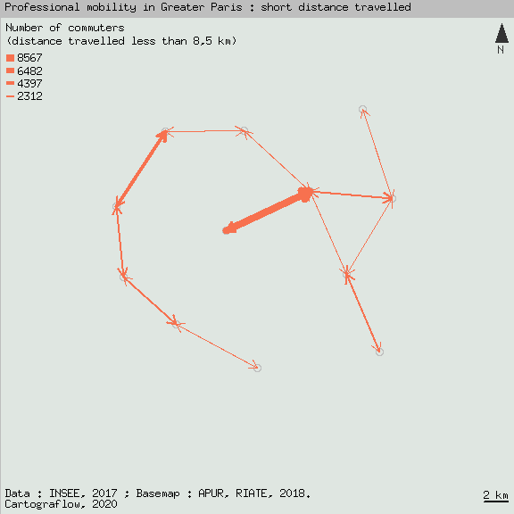

```r
#Map legend
legendPropLines(pos="topleft",
                title.txt="Number of commuters\n(distance travelled less than 8,5 km)",
                title.cex=0.8,
                cex=0.5,
                values.cex= 0.7,
                var=c(min(flow.d$flowfilter),8567),
                col="#f7714f",
                lwd=8,
                frame = FALSE,
                values.rnd = 0
                )

#Map cosmetic
layoutLayer(title = "Professional mobility in Greater Paris : short distance travelled",
            author = "Cartograflow, 2020",
            sources = "Data : INSEE, 2017 ; Basemap : APUR, RIATE, 2018.",
            scale = 2,
            tabtitle = FALSE,
            frame = TRUE,
            col = "grey",
            coltitle ="black"
            )

# north arrow
north("topright")
```

## **Flowmap reduction and filtering according to distance matrix**

Using the `flowreduct()` *d.criteria as “dmax” distance parameter **in association with a `flowmap()`** _“threshold”_** value to map flows between two values (here between the first and third quartiles [Q1 - Q3]) - Not show.

### 6. Filtering flows by ordinal distance travelled

Filtering an Origin-Destination matrix with an **ordinal distance matrix**. This matrix describes a neighborhood space defined by a number (k) of boundaries to be crossed in order to reach a place of destination from a place of origin. The aim is to map local flows that are either adjacent or located at low (k).

**Main function**

`flowcontig()`

**Useful additional function**

`flowreduct()` with the `metric` parameter: *“ordinal”*.

**Computes the neighbouring graph**

Example is for neighbouring areas which share a common boundary (k=1)

```r
library(igraph)
## Neighbouring graph (order k= 1)
graph_ckij_1<-flowcontig(bkg=map, code="EPT_NUM",
                         k=1, algo = "automatic")
```

```
## [1] "ordre max = 3"
```

```r
#Max order = "3"
```

**Flow reduction according to the neighbouring graph**

Reducing flow matrix by the neighbouring graph (k=1)

```r
library(rlang)

#head(tabflow)
#head(graph_ckij_1)

reduc_k1<-flowreduct(tabflow,
                  graph_ckij_1,
                  metric = "ordinal")
head(reduc_k1)
```

```
##    i   j  flow ordre.c
## 1 T1 T10  8297       1
## 2 T1 T12 17064       1
## 3 T1  T2 12163       1
## 4 T1  T3 32682       1
## 5 T1  T4 81129       1
## 6 T1  T5 16622       1
```

**Flowmap between adjacent areas**

Using (k=1) parameter

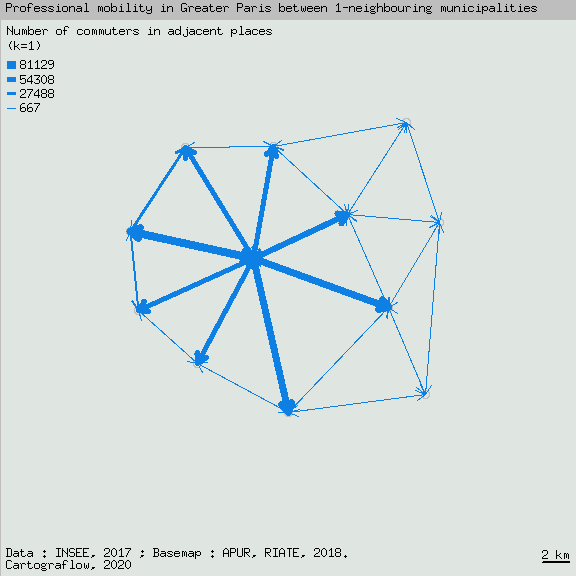

```r
# Graphic parameters
knitr::opts_chunk$set(fig.width=6, fig.height=6)
par(mar=c(0,0,1,0))
extent <- c(2800000, 1340000, 6400000, 4800000)
resolution<-150

# Overlay a spatial background
par(bg = "NA")

# Add the corresponding background
plot(st_geometry(map), col = NA, border=NA, bg="#dfe6e1")
plot(st_geometry(map), col = "light grey", add=TRUE)

#Flowmap : flow travelled between adjacent areas

flowmap(tab=reduc_k1,
        fij="flow",origin.f = "i",destination.f = "j",
        bkg = map,code="EPT_NUM",nodes.X="X",nodes.Y = "Y",
        filter=TRUE,
        taille=8,
        a.head = 1,
        a.length = 0.11,
        a.col="#0e7fe3",
        add=TRUE
        )

# Map Legend
legendPropLines(pos="topleft",
                title.txt="Number of commuters in adjacent places\n(k=1)",
                title.cex=0.8,
                cex=0.5,
                values.cex= 0.7,
                var=c(min(reduc_k1$flow),max(reduc_k1$flow)),
                col="#0e7fe3",
                lwd=8,
                frame = FALSE,
                values.rnd = 0
                )

# Map cosmetic
layoutLayer(title = "Professional mobility in Greater Paris between 1-neighbouring municipalities",
            author = "Cartograflow, 2020",
            sources = "Data : INSEE, 2017 ; Basemap : APUR, RIATE, 2018.",
            scale = 2,
            tabtitle = FALSE,
            frame = TRUE,
            col = "grey",
            coltitle ="black")
```

**Flowmap reducing and filtering according to ordinal matrix**

```r
#Computes k=1
library(igraph)

#Neighbouring graph k=1
graph_ckij_1<-flowcontig(bkg=map, code="EPT_NUM",k=1)
```

```
## [1] "ordre max = 3"
```

```r
#Flow reduction
reduc_k1<-flowreduct(tabflow,
                  graph_ckij_1,
                  metric = "ordinal")

#Mean flow value
reduc_k1_mean<-mean(reduc_k1$flow)
mean<-mean(tabflow$Fij)

# mean value of reduc_k1_mean =18591
# mean value of tabflow =13220
```

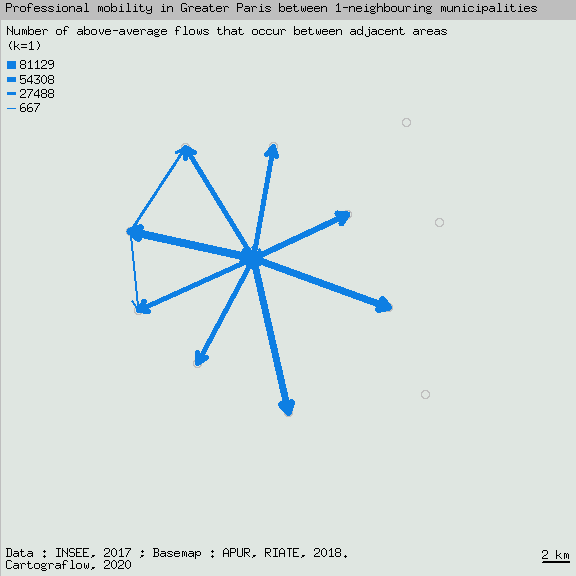

```r
# Graphic parameters
knitr::opts_chunk$set(fig.width=6, fig.height=6)
par(mar=c(0,0,1,0))
extent <- c(2800000, 1340000, 6400000, 4800000)
resolution<-150

# Overlay a spatial background
par(bg = "NA")

# Add the corresponding background
plot(st_geometry(map), col = NA, border=NA, bg="#dfe6e1")
plot(st_geometry(map), col = "light grey", add=TRUE)

#Flowmap : flow travelled between adjacent areas

flowmap(tab=reduc_k1,
        fij="flow",origin.f = "i",destination.f = "j",
        bkg = map,code="EPT_NUM",nodes.X="X",nodes.Y = "Y",
        filter=TRUE,
        threshold = 13220, #reduc_k1 mean value is 18591 ; tabflow mean value is 13220
        taille=8,
        a.head = 1,
        a.length = 0.11,
        a.col="#0e7fe3",
        add=TRUE
        )

# Map Legend
legendPropLines(pos="topleft",
                title.txt="Number of above-average flows that occur between adjacent areas\n(k=1)",
                title.cex=0.8,
                cex=0.5,
                values.cex= 0.7,
                var=c(min(reduc_k1$flow),max(reduc_k1$flow)),
                col="#0e7fe3",
                lwd=8,
                frame = FALSE,
                values.rnd = 0
                )

# Map cosmetic
layoutLayer(title = "Professional mobility in Greater Paris between 1-neighbouring municipalities",
            author = "Cartograflow, 2020",
            sources = "Data : INSEE, 2017 ; Basemap : APUR, RIATE, 2018.",
            scale = 2,
            tabtitle = FALSE,
            frame = TRUE,
            col = "grey",
            coltitle ="black")
```

## C- Sample datasets

– *Statistical dataset* :  
- INSEE - Base flux de mobilité (2015) - URL : https://www.insee.fr/fr/statistiques/fichier/3566008/rp2015_mobpro_txt.zip

– *Geographical dataset* : - municipalities : IGN, GEOFLA 2015 v2.1 - Greater Paris : APUR, UMS 2414 RIATE, 2018.

[output not shown]